# Risk Factor Analysis

## Outcome Variable

**Outcome Variable:** wasted

## Predictor Variables

**Intervention Variable:** predexfd6

**Adjustment Set:**

- arm
- sex
- W_mage
- meducyrs
- feducyrs
- hhwealth_quart
- hfoodsec
- W_mhtcm
- vagbrth
- W_gagebrth
- W_birthwt
- W_birthlen
- W_nrooms
- W_nchldlt5
- month
- brthmon
- W_parity
- impfloor
- impsan
- safeh20
- delta_W_mage
- delta_meducyrs
- delta_feducyrs
- delta_hhwealth_quart
- delta_hfoodsec
- delta_W_mhtcm
- delta_vagbrth
- delta_W_gagebrth
- delta_W_birthwt
- delta_W_birthlen
- delta_W_nrooms
- delta_W_nchldlt5
- delta_month
- delta_brthmon
- delta_W_parity
- delta_impfloor
- delta_impsan
- delta_safeh20

## Stratifying Variables

The analysis was stratified on these variable(s):

- agecat
- studyid
- country

## Data Summary

| agecat | studyid | country | predexfd6 | wasted | n_cell | n |
| --- | --- | --- | --- | --- | --- | --- |
| Birth | ki0047075b-MAL-ED | BANGLADESH | 0 | 0 | 83 | 219 |
| Birth | ki0047075b-MAL-ED | BANGLADESH | 0 | 1 | 22 | 219 |
| Birth | ki0047075b-MAL-ED | BANGLADESH | 1 | 0 | 98 | 219 |
| Birth | ki0047075b-MAL-ED | BANGLADESH | 1 | 1 | 16 | 219 |
| Birth | ki0047075b-MAL-ED | BRAZIL | 0 | 0 | 136 | 168 |
| Birth | ki0047075b-MAL-ED | BRAZIL | 0 | 1 | 6 | 168 |
| Birth | ki0047075b-MAL-ED | BRAZIL | 1 | 0 | 26 | 168 |
| Birth | ki0047075b-MAL-ED | BRAZIL | 1 | 1 | 0 | 168 |
| Birth | ki0047075b-MAL-ED | INDIA | 0 | 0 | 144 | 187 |
| Birth | ki0047075b-MAL-ED | INDIA | 0 | 1 | 28 | 187 |
| Birth | ki0047075b-MAL-ED | INDIA | 1 | 0 | 13 | 187 |
| Birth | ki0047075b-MAL-ED | INDIA | 1 | 1 | 2 | 187 |
| Birth | ki0047075b-MAL-ED | NEPAL | 0 | 0 | 124 | 165 |
| Birth | ki0047075b-MAL-ED | NEPAL | 0 | 1 | 19 | 165 |
| Birth | ki0047075b-MAL-ED | NEPAL | 1 | 0 | 21 | 165 |
| Birth | ki0047075b-MAL-ED | NEPAL | 1 | 1 | 1 | 165 |
| Birth | ki0047075b-MAL-ED | PERU | 0 | 0 | 141 | 249 |
| Birth | ki0047075b-MAL-ED | PERU | 0 | 1 | 4 | 249 |
| Birth | ki0047075b-MAL-ED | PERU | 1 | 0 | 103 | 249 |
| Birth | ki0047075b-MAL-ED | PERU | 1 | 1 | 1 | 249 |
| Birth | ki0047075b-MAL-ED | SOUTH AFRICA | 0 | 0 | 192 | 209 |
| Birth | ki0047075b-MAL-ED | SOUTH AFRICA | 0 | 1 | 14 | 209 |
| Birth | ki0047075b-MAL-ED | SOUTH AFRICA | 1 | 0 | 3 | 209 |
| Birth | ki0047075b-MAL-ED | SOUTH AFRICA | 1 | 1 | 0 | 209 |
| Birth | ki0047075b-MAL-ED | TANZANIA, UNITED REPUBLIC OF | 0 | 0 | 112 | 115 |
| Birth | ki0047075b-MAL-ED | TANZANIA, UNITED REPUBLIC OF | 0 | 1 | 2 | 115 |
| Birth | ki0047075b-MAL-ED | TANZANIA, UNITED REPUBLIC OF | 1 | 0 | 1 | 115 |
| Birth | ki0047075b-MAL-ED | TANZANIA, UNITED REPUBLIC OF | 1 | 1 | 0 | 115 |
| Birth | ki1000108-CMC-V-BCS-2002 | INDIA | 0 | 0 | 0 | 7 |
| Birth | ki1000108-CMC-V-BCS-2002 | INDIA | 0 | 1 | 0 | 7 |

[output cut: 158 more lines]

The following strata were considered:

- agecat: 24 months, studyid: ki0047075b-MAL-ED, country: BANGLADESH
- agecat: 24 months, studyid: ki0047075b-MAL-ED, country: BRAZIL
- agecat: 24 months, studyid: ki0047075b-MAL-ED, country: INDIA
- agecat: 24 months, studyid: ki0047075b-MAL-ED, country: NEPAL
- agecat: 24 months, studyid: ki0047075b-MAL-ED, country: PERU
- agecat: 24 months, studyid: ki0047075b-MAL-ED, country: SOUTH AFRICA
- agecat: 24 months, studyid: ki0047075b-MAL-ED, country: TANZANIA, UNITED REPUBLIC OF
- agecat: 24 months, studyid: ki1000108-CMC-V-BCS-2002, country: INDIA
- agecat: 24 months, studyid: ki1000108-IRC, country: INDIA
- agecat: 24 months, studyid: ki1017093b-PROVIDE, country: BANGLADESH
- agecat: 24 months, studyid: ki1101329-Keneba, country: GAMBIA
- agecat: 24 months, studyid: ki1113344-GMS-Nepal, country: NEPAL
- agecat: 24 months, studyid: ki1148112-LCNI-5, country: MALAWI
- agecat: 24 months, studyid: kiGH5241-JiVitA-3, country: BANGLADESH
- agecat: 24 months, studyid: kiGH5241-JiVitA-4, country: BANGLADESH
- agecat: 6 months, studyid: ki0047075b-MAL-ED, country: BANGLADESH
- agecat: 6 months, studyid: ki0047075b-MAL-ED, country: BRAZIL
- agecat: 6 months, studyid: ki0047075b-MAL-ED, country: INDIA
- agecat: 6 months, studyid: ki0047075b-MAL-ED, country: NEPAL
- agecat: 6 months, studyid: ki0047075b-MAL-ED, country: PERU
- agecat: 6 months, studyid: ki0047075b-MAL-ED, country: SOUTH AFRICA
- agecat: 6 months, studyid: ki0047075b-MAL-ED, country: TANZANIA, UNITED REPUBLIC OF
- agecat: 6 months, studyid: ki1000108-CMC-V-BCS-2002, country: INDIA
- agecat: 6 months, studyid: ki1000108-IRC, country: INDIA
- agecat: 6 months, studyid: ki1000109-EE, country: PAKISTAN
- agecat: 6 months, studyid: ki1000304b-SAS-CompFeed, country: INDIA
- agecat: 6 months, studyid: ki1000304b-SAS-FoodSuppl, country: INDIA
- agecat: 6 months, studyid: ki1017093b-PROVIDE, country: BANGLADESH
- agecat: 6 months, studyid: ki1101329-Keneba, country: GAMBIA
- agecat: 6 months, studyid: ki1113344-GMS-Nepal, country: NEPAL
- agecat: 6 months, studyid: ki1148112-LCNI-5, country: MALAWI
- agecat: 6 months, studyid: kiGH5241-JiVitA-3, country: BANGLADESH
- agecat: 6 months, studyid: kiGH5241-JiVitA-4, country: BANGLADESH
- agecat: Birth, studyid: ki0047075b-MAL-ED, country: BANGLADESH
- agecat: Birth, studyid: ki0047075b-MAL-ED, country: BRAZIL
- agecat: Birth, studyid: ki0047075b-MAL-ED, country: INDIA
- agecat: Birth, studyid: ki0047075b-MAL-ED, country: NEPAL
- agecat: Birth, studyid: ki0047075b-MAL-ED, country: PERU
- agecat: Birth, studyid: ki0047075b-MAL-ED, country: SOUTH AFRICA
- agecat: Birth, studyid: ki0047075b-MAL-ED, country: TANZANIA, UNITED REPUBLIC OF
- agecat: Birth, studyid: ki1000108-CMC-V-BCS-2002, country: INDIA
- agecat: Birth, studyid: ki1000108-IRC, country: INDIA
- agecat: Birth, studyid: ki1000109-EE, country: PAKISTAN
- agecat: Birth, studyid: ki1000304b-SAS-CompFeed, country: INDIA
- agecat: Birth, studyid: ki1101329-Keneba, country: GAMBIA
- agecat: Birth, studyid: kiGH5241-JiVitA-3, country: BANGLADESH
- agecat: Birth, studyid: kiGH5241-JiVitA-4, country: BANGLADESH

### Dropped Strata

Some strata were dropped due to rare outcomes:

- agecat: Birth, studyid: ki0047075b-MAL-ED, country: BRAZIL
- agecat: Birth, studyid: ki0047075b-MAL-ED, country: INDIA
- agecat: Birth, studyid: ki0047075b-MAL-ED, country: NEPAL
- agecat: Birth, studyid: ki0047075b-MAL-ED, country: PERU
- agecat: Birth, studyid: ki0047075b-MAL-ED, country: SOUTH AFRICA
- agecat: Birth, studyid: ki0047075b-MAL-ED, country: TANZANIA, UNITED REPUBLIC OF
- agecat: Birth, studyid: ki1000108-CMC-V-BCS-2002, country: INDIA
- agecat: Birth, studyid: ki1000108-IRC, country: INDIA
- agecat: Birth, studyid: ki1000109-EE, country: PAKISTAN
- agecat: Birth, studyid: ki1000304b-SAS-CompFeed, country: INDIA
- agecat: 6 months, studyid: ki0047075b-MAL-ED, country: BANGLADESH
- agecat: 6 months, studyid: ki0047075b-MAL-ED, country: BRAZIL
- agecat: 6 months, studyid: ki0047075b-MAL-ED, country: INDIA
- agecat: 6 months, studyid: ki0047075b-MAL-ED, country: NEPAL
- agecat: 6 months, studyid: ki0047075b-MAL-ED, country: PERU
- agecat: 6 months, studyid: ki0047075b-MAL-ED, country: SOUTH AFRICA
- agecat: 6 months, studyid: ki0047075b-MAL-ED, country: TANZANIA, UNITED REPUBLIC OF
- agecat: 6 months, studyid: ki1000108-CMC-V-BCS-2002, country: INDIA
- agecat: 6 months, studyid: ki1000108-IRC, country: INDIA
- agecat: 6 months, studyid: ki1000304b-SAS-CompFeed, country: INDIA
- agecat: 6 months, studyid: ki1000304b-SAS-FoodSuppl, country: INDIA
- agecat: 6 months, studyid: ki1017093b-PROVIDE, country: BANGLADESH
- agecat: 6 months, studyid: ki1148112-LCNI-5, country: MALAWI
- agecat: 24 months, studyid: ki0047075b-MAL-ED, country: BRAZIL
- agecat: 24 months, studyid: ki0047075b-MAL-ED, country: INDIA
- agecat: 24 months, studyid: ki0047075b-MAL-ED, country: NEPAL
- agecat: 24 months, studyid: ki0047075b-MAL-ED, country: PERU
- agecat: 24 months, studyid: ki0047075b-MAL-ED, country: SOUTH AFRICA
- agecat: 24 months, studyid: ki0047075b-MAL-ED, country: TANZANIA, UNITED REPUBLIC OF
- agecat: 24 months, studyid: ki1000108-CMC-V-BCS-2002, country: INDIA
- agecat: 24 months, studyid: ki1000108-IRC, country: INDIA
- agecat: 24 months, studyid: ki1148112-LCNI-5, country: MALAWI

## Methods Detail

We’re interested in the causal parameters $E[Y_a]$ for all values of $a \in \mathcal{A}$. These parameters represent the mean outcome if, possibly contrary to fact, we intervened to set all units to have $A=a$. Under the randomization and positivity assumptions, these are identified by the statistical parameters $\psi_a=E_W[E_{Y|A,W}(Y|A=a,W)]$. In addition, we’re interested in the mean of $Y$, $E[Y]$ under no intervention (the observed mean). We will estimate these parameters by using SuperLearner to fit the relevant likelihood factors – $E_{Y|A,W}(Y|A=a,W)$ and $p(A=a|W)$, and then updating our likelihood fit using a joint TMLE.

For unadjusted analyses ($W=\{\}$), initial likelihoods were estimated using Lrnr_glm to estimate the simple $E(Y|A)$ and Lrnr_mean to estimate $p(A)$. For adjusted analyses, a small library containing Lrnr_glmnet, Lrnr_xgboost, and Lrnr_mean was used.

Having estimated these parameters, we will then use the delta method to estimate relative risks and attributable risks relative to a prespecified baseline level of $A$.

# Results Detail

## Results Plots

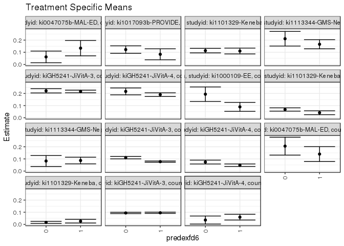

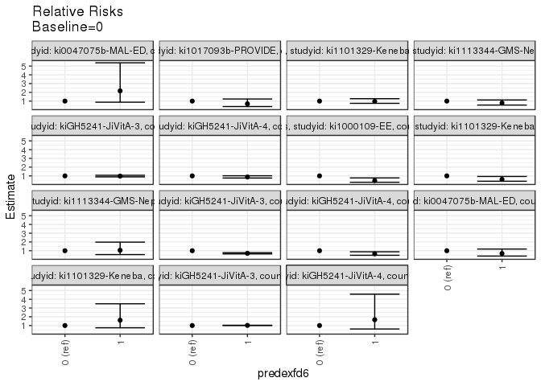

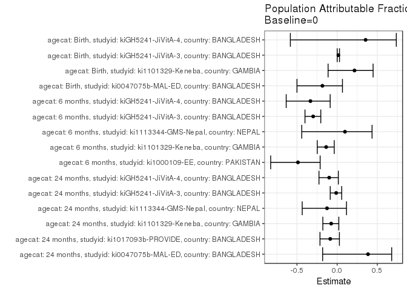

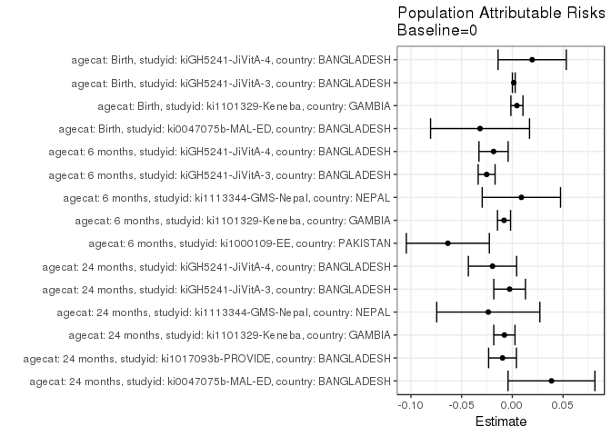

## Results Table

### Parameter: TSM

| agecat | studyid | country | intervention_level | baseline_level | estimate | ci_lower | ci_upper |
| --- | --- | --- | --- | --- | --- | --- | --- |
| Birth | ki0047075b-MAL-ED | BANGLADESH | 0 | NA | 0.2053395 | 0.1315874 | 0.2790916 |
| Birth | ki0047075b-MAL-ED | BANGLADESH | 1 | NA | 0.1398940 | 0.0786539 | 0.2011342 |
| Birth | ki1101329-Keneba | GAMBIA | 0 | NA | 0.0164295 | 0.0079756 | 0.0248834 |
| Birth | ki1101329-Keneba | GAMBIA | 1 | NA | 0.0264599 | 0.0112389 | 0.0416809 |
| Birth | kiGH5241-JiVitA-3 | BANGLADESH | 0 | NA | 0.0940877 | 0.0887686 | 0.0994067 |
| Birth | kiGH5241-JiVitA-3 | BANGLADESH | 1 | NA | 0.0954849 | 0.0902504 | 0.1007194 |
| Birth | kiGH5241-JiVitA-4 | BANGLADESH | 0 | NA | 0.0357143 | 0.0025801 | 0.0688485 |
| Birth | kiGH5241-JiVitA-4 | BANGLADESH | 1 | NA | 0.0595010 | 0.0357033 | 0.0832986 |
| 6 months | ki1000109-EE | PAKISTAN | 0 | NA | 0.1939046 | 0.1340521 | 0.2537571 |
| 6 months | ki1000109-EE | PAKISTAN | 1 | NA | 0.0895266 | 0.0526599 | 0.1263934 |
| 6 months | ki1101329-Keneba | GAMBIA | 0 | NA | 0.0679301 | 0.0543851 | 0.0814751 |
| 6 months | ki1101329-Keneba | GAMBIA | 1 | NA | 0.0410342 | 0.0250787 | 0.0569896 |
| 6 months | ki1113344-GMS-Nepal | NEPAL | 0 | NA | 0.0826467 | 0.0372769 | 0.1280164 |
| 6 months | ki1113344-GMS-Nepal | NEPAL | 1 | NA | 0.0869014 | 0.0593728 | 0.1144301 |
| 6 months | kiGH5241-JiVitA-3 | BANGLADESH | 0 | NA | 0.1102993 | 0.1004017 | 0.1201968 |
| 6 months | kiGH5241-JiVitA-3 | BANGLADESH | 1 | NA | 0.0775320 | 0.0724794 | 0.0825846 |
| 6 months | kiGH5241-JiVitA-4 | BANGLADESH | 0 | NA | 0.0741342 | 0.0581749 | 0.0900935 |
| 6 months | kiGH5241-JiVitA-4 | BANGLADESH | 1 | NA | 0.0481177 | 0.0376519 | 0.0585835 |
| 24 months | ki0047075b-MAL-ED | BANGLADESH | 0 | NA | 0.0618557 | 0.0138018 | 0.1099095 |
| 24 months | ki0047075b-MAL-ED | BANGLADESH | 1 | NA | 0.1339286 | 0.0707028 | 0.1971543 |
| 24 months | ki1017093b-PROVIDE | BANGLADESH | 0 | NA | 0.1221282 | 0.0912983 | 0.1529581 |
| 24 months | ki1017093b-PROVIDE | BANGLADESH | 1 | NA | 0.0833152 | 0.0381359 | 0.1284945 |
| 24 months | ki1101329-Keneba | GAMBIA | 0 | NA | 0.1135177 | 0.0946404 | 0.1323949 |
| 24 months | ki1101329-Keneba | GAMBIA | 1 | NA | 0.1102839 | 0.0861713 | 0.1343965 |
| 24 months | ki1113344-GMS-Nepal | NEPAL | 0 | NA | 0.2115773 | 0.1512792 | 0.2718754 |
| 24 months | ki1113344-GMS-Nepal | NEPAL | 1 | NA | 0.1660712 | 0.1284074 | 0.2037350 |
| 24 months | kiGH5241-JiVitA-3 | BANGLADESH | 0 | NA | 0.2217398 | 0.2040168 | 0.2394629 |
| 24 months | kiGH5241-JiVitA-3 | BANGLADESH | 1 | NA | 0.2164336 | 0.2054991 | 0.2273681 |
| 24 months | kiGH5241-JiVitA-4 | BANGLADESH | 0 | NA | 0.2169484 | 0.1885094 | 0.2453874 |
| 24 months | kiGH5241-JiVitA-4 | BANGLADESH | 1 | NA | 0.1902096 | 0.1750705 | 0.2053487 |

### Parameter: E(Y)

| agecat | studyid | country | intervention_level | baseline_level | estimate | ci_lower | ci_upper |
| --- | --- | --- | --- | --- | --- | --- | --- |
| Birth | ki0047075b-MAL-ED | BANGLADESH | NA | NA | 0.1735160 | 0.1232462 | 0.2237857 |
| Birth | ki1101329-Keneba | GAMBIA | NA | NA | 0.0209581 | 0.0132741 | 0.0286420 |
| Birth | kiGH5241-JiVitA-3 | BANGLADESH | NA | NA | 0.0955253 | 0.0903072 | 0.1007433 |
| Birth | kiGH5241-JiVitA-4 | BANGLADESH | NA | NA | 0.0552923 | 0.0348344 | 0.0757501 |
| 6 months | ki1000109-EE | PAKISTAN | NA | NA | 0.1303191 | 0.0962457 | 0.1643926 |
| 6 months | ki1101329-Keneba | GAMBIA | NA | NA | 0.0597484 | 0.0491105 | 0.0703864 |
| 6 months | ki1113344-GMS-Nepal | NEPAL | NA | NA | 0.0915751 | 0.0673602 | 0.1157900 |
| 6 months | kiGH5241-JiVitA-3 | BANGLADESH | NA | NA | 0.0849595 | 0.0801414 | 0.0897775 |
| 6 months | kiGH5241-JiVitA-4 | BANGLADESH | NA | NA | 0.0556338 | 0.0463917 | 0.0648759 |
| 24 months | ki0047075b-MAL-ED | BANGLADESH | NA | NA | 0.1004785 | 0.0596222 | 0.1413347 |
| 24 months | ki1017093b-PROVIDE | BANGLADESH | NA | NA | 0.1124567 | 0.0866788 | 0.1382347 |
| 24 months | ki1101329-Keneba | GAMBIA | NA | NA | 0.1056803 | 0.0901896 | 0.1211711 |
| 24 months | ki1113344-GMS-Nepal | NEPAL | NA | NA | 0.1878914 | 0.1528732 | 0.2229097 |
| 24 months | kiGH5241-JiVitA-3 | BANGLADESH | NA | NA | 0.2190767 | 0.2091475 | 0.2290059 |
| 24 months | kiGH5241-JiVitA-4 | BANGLADESH | NA | NA | 0.1974032 | 0.1830515 | 0.2117549 |

### Parameter: RR

| agecat | studyid | country | intervention_level | baseline_level | estimate | ci_lower | ci_upper |
| --- | --- | --- | --- | --- | --- | --- | --- |
| Birth | ki0047075b-MAL-ED | BANGLADESH | 0 | 0 | 1.0000000 | 1.0000000 | 1.0000000 |
| Birth | ki0047075b-MAL-ED | BANGLADESH | 1 | 0 | 0.6812816 | 0.3900067 | 1.1900939 |
| Birth | ki1101329-Keneba | GAMBIA | 0 | 0 | 1.0000000 | 1.0000000 | 1.0000000 |
| Birth | ki1101329-Keneba | GAMBIA | 1 | 0 | 1.6105151 | 0.7441642 | 3.4854661 |
| Birth | kiGH5241-JiVitA-3 | BANGLADESH | 0 | 0 | 1.0000000 | 1.0000000 | 1.0000000 |
| Birth | kiGH5241-JiVitA-3 | BANGLADESH | 1 | 0 | 1.0148506 | 0.9958464 | 1.0342174 |
| Birth | kiGH5241-JiVitA-4 | BANGLADESH | 0 | 0 | 1.0000000 | 1.0000000 | 1.0000000 |
| Birth | kiGH5241-JiVitA-4 | BANGLADESH | 1 | 0 | 1.6660269 | 0.6055423 | 4.5837352 |
| 6 months | ki1000109-EE | PAKISTAN | 0 | 0 | 1.0000000 | 1.0000000 | 1.0000000 |
| 6 months | ki1000109-EE | PAKISTAN | 1 | 0 | 0.4617044 | 0.2761967 | 0.7718085 |
| 6 months | ki1101329-Keneba | GAMBIA | 0 | 0 | 1.0000000 | 1.0000000 | 1.0000000 |
| 6 months | ki1101329-Keneba | GAMBIA | 1 | 0 | 0.6040648 | 0.3904009 | 0.9346655 |
| 6 months | ki1113344-GMS-Nepal | NEPAL | 0 | 0 | 1.0000000 | 1.0000000 | 1.0000000 |
| 6 months | ki1113344-GMS-Nepal | NEPAL | 1 | 0 | 1.0514810 | 0.5587122 | 1.9788581 |
| 6 months | kiGH5241-JiVitA-3 | BANGLADESH | 0 | 0 | 1.0000000 | 1.0000000 | 1.0000000 |
| 6 months | kiGH5241-JiVitA-3 | BANGLADESH | 1 | 0 | 0.7029242 | 0.6319939 | 0.7818151 |
| 6 months | kiGH5241-JiVitA-4 | BANGLADESH | 0 | 0 | 1.0000000 | 1.0000000 | 1.0000000 |
| 6 months | kiGH5241-JiVitA-4 | BANGLADESH | 1 | 0 | 0.6490620 | 0.4791843 | 0.8791638 |
| 24 months | ki0047075b-MAL-ED | BANGLADESH | 0 | 0 | 1.0000000 | 1.0000000 | 1.0000000 |
| 24 months | ki0047075b-MAL-ED | BANGLADESH | 1 | 0 | 2.1651786 | 0.8723550 | 5.3739567 |
| 24 months | ki1017093b-PROVIDE | BANGLADESH | 0 | 0 | 1.0000000 | 1.0000000 | 1.0000000 |
| 24 months | ki1017093b-PROVIDE | BANGLADESH | 1 | 0 | 0.6821948 | 0.3750981 | 1.2407148 |
| 24 months | ki1101329-Keneba | GAMBIA | 0 | 0 | 1.0000000 | 1.0000000 | 1.0000000 |
| 24 months | ki1101329-Keneba | GAMBIA | 1 | 0 | 0.9715129 | 0.7417123 | 1.2725113 |
| 24 months | ki1113344-GMS-Nepal | NEPAL | 0 | 0 | 1.0000000 | 1.0000000 | 1.0000000 |
| 24 months | ki1113344-GMS-Nepal | NEPAL | 1 | 0 | 0.7849198 | 0.5458181 | 1.1287628 |
| 24 months | kiGH5241-JiVitA-3 | BANGLADESH | 0 | 0 | 1.0000000 | 1.0000000 | 1.0000000 |
| 24 months | kiGH5241-JiVitA-3 | BANGLADESH | 1 | 0 | 0.9760698 | 0.8898791 | 1.0706087 |
| 24 months | kiGH5241-JiVitA-4 | BANGLADESH | 0 | 0 | 1.0000000 | 1.0000000 | 1.0000000 |
| 24 months | kiGH5241-JiVitA-4 | BANGLADESH | 1 | 0 | 0.8767503 | 0.7560883 | 1.0166685 |

### Parameter: PAR

| agecat | studyid | country | intervention_level | baseline_level | estimate | ci_lower | ci_upper |
| --- | --- | --- | --- | --- | --- | --- | --- |
| Birth | ki0047075b-MAL-ED | BANGLADESH | 0 | NA | -0.0318235 | -0.0806195 | 0.0169724 |
| Birth | ki1101329-Keneba | GAMBIA | 0 | NA | 0.0045286 | -0.0014132 | 0.0104704 |
| Birth | kiGH5241-JiVitA-3 | BANGLADESH | 0 | NA | 0.0014376 | 0.0000551 | 0.0028202 |
| Birth | kiGH5241-JiVitA-4 | BANGLADESH | 0 | NA | 0.0195780 | -0.0140625 | 0.0532184 |
| 6 months | ki1000109-EE | PAKISTAN | 0 | NA | -0.0635855 | -0.1045222 | -0.0226487 |
| 6 months | ki1101329-Keneba | GAMBIA | 0 | NA | -0.0081817 | -0.0146291 | -0.0017342 |
| 6 months | ki1113344-GMS-Nepal | NEPAL | 0 | NA | 0.0089284 | -0.0296825 | 0.0475393 |
| 6 months | kiGH5241-JiVitA-3 | BANGLADESH | 0 | NA | -0.0253398 | -0.0336632 | -0.0170163 |
| 6 months | kiGH5241-JiVitA-4 | BANGLADESH | 0 | NA | -0.0185004 | -0.0328823 | -0.0041184 |
| 24 months | ki0047075b-MAL-ED | BANGLADESH | 0 | NA | 0.0386228 | -0.0042137 | 0.0814593 |
| 24 months | ki1017093b-PROVIDE | BANGLADESH | 0 | NA | -0.0096714 | -0.0233660 | 0.0040231 |
| 24 months | ki1101329-Keneba | GAMBIA | 0 | NA | -0.0078374 | -0.0182961 | 0.0026213 |
| 24 months | ki1113344-GMS-Nepal | NEPAL | 0 | NA | -0.0236858 | -0.0745406 | 0.0271689 |
| 24 months | kiGH5241-JiVitA-3 | BANGLADESH | 0 | NA | -0.0026631 | -0.0182744 | 0.0129481 |
| 24 months | kiGH5241-JiVitA-4 | BANGLADESH | 0 | NA | -0.0195452 | -0.0433390 | 0.0042486 |

### Parameter: PAF

| agecat | studyid | country | intervention_level | baseline_level | estimate | ci_lower | ci_upper |
| --- | --- | --- | --- | --- | --- | --- | --- |
| Birth | ki0047075b-MAL-ED | BANGLADESH | 0 | NA | -0.1834041 | -0.4999163 | 0.0663178 |
| Birth | ki1101329-Keneba | GAMBIA | 0 | NA | 0.2160788 | -0.1127434 | 0.4477321 |
| Birth | kiGH5241-JiVitA-3 | BANGLADESH | 0 | NA | 0.0150498 | 0.0004949 | 0.0293928 |
| Birth | kiGH5241-JiVitA-4 | BANGLADESH | 0 | NA | 0.3540816 | -0.5823543 | 0.7363356 |
| 6 months | ki1000109-EE | PAKISTAN | 0 | NA | -0.4879212 | -0.8274510 | -0.2114741 |
| 6 months | ki1101329-Keneba | GAMBIA | 0 | NA | -0.1369352 | -0.2475197 | -0.0361533 |
| 6 months | ki1113344-GMS-Nepal | NEPAL | 0 | NA | 0.0974982 | -0.4407763 | 0.4346732 |
| 6 months | kiGH5241-JiVitA-3 | BANGLADESH | 0 | NA | -0.2982574 | -0.4003489 | -0.2036089 |
| 6 months | kiGH5241-JiVitA-4 | BANGLADESH | 0 | NA | -0.3325385 | -0.6341326 | -0.0866064 |
| 24 months | ki0047075b-MAL-ED | BANGLADESH | 0 | NA | 0.3843888 | -0.1805817 | 0.6789912 |
| 24 months | ki1017093b-PROVIDE | BANGLADESH | 0 | NA | -0.0860014 | -0.2135721 | 0.0281591 |
| 24 months | ki1101329-Keneba | GAMBIA | 0 | NA | -0.0741611 | -0.1782253 | 0.0207118 |
| 24 months | ki1113344-GMS-Nepal | NEPAL | 0 | NA | -0.1260613 | -0.4347901 | 0.1162372 |
| 24 months | kiGH5241-JiVitA-3 | BANGLADESH | 0 | NA | -0.0121562 | -0.0860400 | 0.0567013 |
| 24 months | kiGH5241-JiVitA-4 | BANGLADESH | 0 | NA | -0.0990115 | -0.2262122 | 0.0149941 |